# Knowledge, Attitudes and Practices on Vector-Borne Diseases in Switzerland – 2025

Lilian Goepp, Nina Huber, Arlette Szelecsenyi, Julien Riou

2025-09-03

```r
analysis_date = "2025-06-26"
load(paste0("savepoints/savepoint_",analysis_date,"/brs_3.Rdata"))
source("R/setup.R")
knitr::opts_chunk$set(echo = FALSE)
set_gtsummary_theme(list(
  "tbl_summary-fn:percent_fun" = function(x) style_percent(x, digits = 1)
))
```

# 1 Introduction

This report presents findings from a survey conducted within the national research program NCCS-Impacts (“Decision Support for Dealing with Climate Change in Switzerland: a cross-sectoral approach”), which develops climate-related services for the environment, the economy, and society. Within this framework, the health project jointly led by the Federal Office of Public Health (FOPH) and the Federal Food Safety and Veterinary Office (FSVO) addresses heat, mycotoxins, and vector-borne diseases in humans and animals (VBDs).

A comprehensive risk assessment of current and future VBD threats to humans and animals in Switzerland is being carried out as part of this effort. It includes documenting both the implementation of measures by cantonal authorities and the knowledge, attitude and practice (KAP) concerning vector-borne diseases among the Bernese population. The general population survey was embedded in the BEready cohort study at the University of Bern. BEready is a long-term study involving households across the canton of Bern, designed to generate data on infectious diseases and improve preparedness for future health threats. In this context, the survey investigates how Bernese residents perceive VBD risks and protective measures, while complementing the national survey of cantonal health, veterinary, and environmental departments on institutional engagement and prevention strategies.

Vector-borne diseases are a growing public-health concern in Switzerland. Tick-borne infections—most notably Lyme borreliosis and tick-borne encephalitis (TBE)—remain the dominant domestic threat, while mosquito-borne diseases such as dengue, West Nile fever, and chikungunya are emerging in neighboring countries. Warmer conditions lengthen vector activity seasons and expand suitable habitats, increasing opportunities for human–vector contact.

Individual preventive measures are essential to limit the transmission of these diseases. Public awareness and knowledge are therefore important factors in planning and implementing public health actions. By collecting data on how Bernese residents perceive these risks and protect themselves, this survey assesses the population’s level of preparedness in the face of this emerging threat. Understanding current behaviors and perceptions will support the development of effective communication and prevention strategies, both to address today’s challenges and to respond to future health impacts.

# 2 Methods

We conducted a cross-sectional, web-based survey of adults (≥18 years) residing in Switzerland in 2025. The survey was implemented within the BEready platform (University of Bern/MCID), which is registered on ClinicalTrials.gov (ID: NCT06739499) and operates as a general population population prospective cohort in the Canton of Bern under a One-Health framework. BEready plans to enrol approximately 1,500 households, including adults, children and pets. A private household is defined as a person living alone or group of persons living in the same dwelling.

Eligible participants were adults (≥18 years) and children who provided informed consent (with parental/legal-guardian consent for minors) and who resided, on average, more than three days per week in a private household in the canton of Bern where at least one household member aged 18 years had agreed to participate. For adults, adolescents aged ≥14 years, and parents/legal guardians, access to the internet (Wi-Fi, fixed, or mobile) and a personal email address was required. For adults, children aged ≥11 years, and parents/legal guardians, sufficient language proficiency to understand, speak, read, and write in German, French, and/or English was required. Individuals were excluded if they had a planned move outside the canton of Bern during the study period. As the vector-borne disease module of the questionnaire was only provided to adults, childrens were not included in this report.

Eligible participants were adults (≥18 years) who provided informed consent and who resided, on average, more than three days per week in a private household in the canton of Bern. Access to the internet (Wi-Fi, fixed, or mobile) and a personal email address was required. Sufficient language proficiency to understand, speak, read, and write in German, French, and/or English was required. Individuals were excluded if they had a planned move outside the canton of Bern during the study period. As the vector-borne disease module of the questionnaire was only provided to adults, childrens were not included in this report.

The study population for the BEready cohort is being enrolled from different sources in the source population of the canton of Bern. BEready aims to enrol around 1,500 households (approx. 2500 individuals) in total from:

- Households already participating in the BEready pilot study
- A random selection of households in Bern using the cantonal residents’ register
- Volunteer households from the general public

At the start of the study, participants have a brief physical checkup and give a blood sample. Immediately after the initial visit and annually thereafter, participants complete an online questionnaire about their current state of health and factors that may make them more susceptible to infections or protect against them, including their knowledge, attitude and practice concerning vector-borne diseases. This report presents preliminary results from the questionnaire filled at enrollement.

Participation in BEready is always voluntary. Participants may leave the study at any time, and BEready complies with Swiss legislation and applicable international guidelines. The study was reviewed and approved by the responsible Ethics Committee. All collected data are processed under strict data-protection standards.

The online survey was implemented using REDCap and description of the data was performed in R (version 4.2.0).

# 3 Results

## 3.1 Sociodemographic variables

The survey sample included 991 respondents, with a sex distribution biased toward females (56.2% female and 43.8% male, p-val <0.001). Gender identification largely mirrored sex assigned at birth, with only 0.4% reporting another gender. Educational attainment was diverse, though skewed toward higher education: 22.7% held a master’s degree, 14.6% a bachelor’s degree, and 8.9% a doctorate. Apprenticeship or vocational training was also common (19.2%). Most respondents (74.9%) had lived in Switzerland since birth, while 19% were born abroad. The majority were married and living with a spouse (55.5%), but single, divorced, or widowed individuals collectively made up nearly 43%. Occupations were varied, with the largest group working in intermediate occupations (39.2%) or administrative support (31.7%), while only 0.5% reported being in senior executive roles. The complete table as well as further details on exposure-related items from the enrollment questionnaire and the geographic distribution of respondents are provided in the Supplementary Material.

## 3.2 General Knowledge

The survey design followed a structured, multi-stage approach to assess public knowledge of vector-borne diseases and their transmission, incorporating both awareness and comprehension measures.

In the first stage, respondents were presented with three items to determine whether they had previously encountered the relevant concepts or understood the underlying concepts:

- An introductory text provided respondents with a definition of vector-borne diseases and the fact that tick-borne encephalitis is a disease transmitted by ticks. Respondents were subsequently asked to classify tick-borne encephalitis as vector-borne or not, serving as an initial measure of their conceptual understanding before advancing to more detailed assessments.
- A disease awareness component, capturing whether respondents reported prior exposure to the names of particular diseases
- A vector awareness component, capturing whether they reported prior exposure to the names of specified organisms.

In the second stage, participants completed classification exercises in which they were required to identify, from structured lists, which diseases they believed were vector-borne and which organisms functioned as vectors.

Establishing the first stage baseline was essential to distinguish between lack of knowledge and misunderstanding in subsequent tasks. To evaluate the robustness of conceptual understanding and to detect systematic misconceptions, distractor items were intentionally included: measles and influenza in the disease set, and wasps and bed bugs in the organism set. These items, while familiar to most respondents, do not fall within the epidemiological definition of vector-borne diseases or recognized disease vectors, and thus provided a validity check. Results from the first stage as well as logical contradiction in the second stage were used to filter out unreliable answers.

When asked to classify tick-borne encephalitis (TBE), which is transmitted through tick bites, 78.4% of respondents correctly recognized it as a vector-borne disease. However, 11% incorrectly denied this classification, while 10.6% stated they did not know. This indicates a generally strong but not universal grasp of the basic definition of vector-borne diseases among the surveyed population. Awareness of diseases varied considerably. Measles (95.4%), influenza (93.7%), and dengue (88.4%) were the most widely recognized. Zika (62.2%) and Lyme disease (75.8%) were moderately well known while West Nile fever (29.3%) and chikungunya (19.7%) were far less familiar. Awareness of potential vectors was consistently high, with ticks (96%), mosquitoes (95.8%), wasps (92.8%), and bed bugs (91.9%) all recognized by most respondents. The corresponding table is provided in the Supplementary Materials.

When asked to classify specific diseases as vector-borne, knowledge levels differed by disease. Correct identification was highest for dengue (86.2%), Lyme disease (82.9%), measles (82.7%, as not vector-borne), and influenza (80.0%, as not vector-borne). Recognition was lower for Zika (68.7%) and especially for West Nile fever (40.6%) and chikungunya (32.3%).

The knowledge score, defined as the proportion of correct answers across three test items assessing recognition of vector-borne diseases, identification of vectors, and disease–vector matching, showed clear variation within the sample. Among the 556 respondents with complete answers to all items, 39 individuals (7.0%) scored below 0.5, indicating low overall knowledge. At the other end of the spectrum, 80 respondents (14.4%) achieved a perfect score of 1, demonstrating complete accuracy across all items. The majority of participants fell between these two extremes: 210 (37.8%) had scores between 0.5 and 0.75, and 227 (40.8%) between 0.75 and 1.0, reflecting moderate to high knowledge with occasional gaps. The distribution of the score suggests that most respondents possess a solid baseline of knowledge concerning ticks, while the biggest knowledge gap concerns mosquito-related items (Supplementary material 2.2)

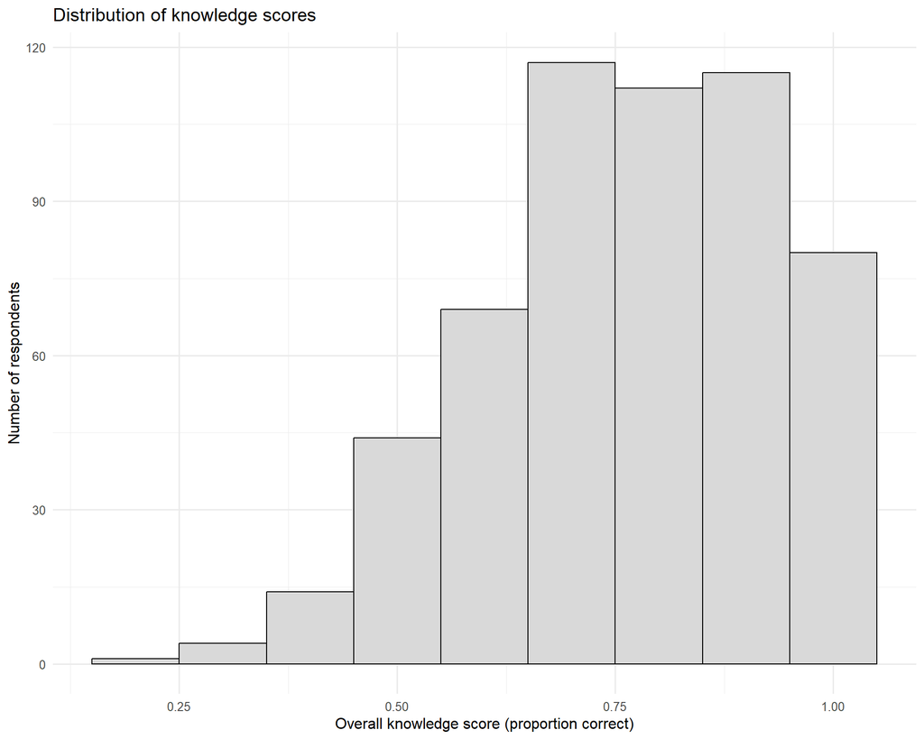

## 3.3 Individual risk exposure

Table 9. Self-reported individual exposure.

| **Question** | **N = 991**<sup>1</sup> |
| --- | --- |
| How many tick bites do you receive on average per year (spring to autumn)? |  |
| 0 | 581 (60.6%) |
| 1–3 | 319 (33.3%) |
| 4–6 | 32 (3.34%) |
| 7–9 | 11 (1.15%) |
| 10+ | 15 (1.57%) |
| (Missing) | 33 |
| In summer, how often are you bitten by mosquitoes? |  |
| Every day | 80 (8.60%) |
| At least weekly | 404 (43.4%) |
| At least monthly | 274 (29.5%) |
| At least yearly | 83 (8.92%) |
| Less than yearly | 22 (2.37%) |
| Never | 13 (1.40%) |
| I don't know | 54 (5.81%) |
| (Missing) | 61 |

<sup>1</sup> n (%)

## 3.4 Individual prevention

Most respondents reported adopting at least one measure against tick bites, particularly checking for and removing ticks (74%) and wearing protective clothing (67%). The use of insect repellent is also commonly reported (48%). Against mosquito bites, the most common strategies were using repellents (65%), wearing protective clothing (44%), and installing window screens (42%). Only 28% of respondents report removing containers of standing water as a personal preventive measure. Around 11% reported taking no measures against mosquitoes, compared to 8% for ticks.

Table 10. Self-reported preventive practices.

| **Question** | **N = 991**<sup>1</sup> |
| --- | --- |
| In the last 12 months, what have you done to protect yourself/family against tick bites or tick-borne diseases? |  |
| Check for and remove ticks after outdoor activities | 737 (74.4%) |
| Wear protective clothing | 659 (66.5%) |
| Use insect repellent on skin or clothing | 479 (48.3%) |
| Avoid wooded areas during tick activity | 126 (12.7%) |
| Other measure: {bl_vbd_oth_meas} | 138 (13.9%) |
| No active measures | 78 (7.87%) |
| (Missing) | 0 |
| In the last 12 months, what have you done to protect yourself/family against mosquito bites? |  |
| Use repellent | 642 (64.8%) |
| Wear protective clothing | 436 (44.0%) |
| Burn mosquito coils | 159 (16.0%) |
| Stay in screened areas | 185 (18.7%) |
| Install window screens | 420 (42.4%) |
| Use fans | 70 (7.06%) |
| Use automatic insect spray | 77 (7.77%) |
| Install bed nets | 143 (14.4%) |
| Remove containers with standing water | 278 (28.1%) |
| Other measure: {bl_vbd_oth_meas_0} | 54 (5.45%) |
| No active measures | 106 (10.7%) |
| (Missing) | 0 |

<sup>1</sup> n (%)

## 3.5 Mitigation strategies and vector control

When asked about effective public-level interventions, respondents placed greater confidence in personal protective measures than in environmental or ecological strategies. For ticks, 78.9% endorsed promoting personal protection, while biological control (38.1%) was the next most supported. Measures targeting wildlife or habitat management received little support (<6%). For mosquitoes, personal protection (75.5%) and elimination of standing water (58.8%) were most often cited, followed by biological control (40.9%) and traps (35.9%). Genetically modified mosquitoes gained support from 17.7%. Overall, confidence leaned strongly toward individual-level protection and simple environmental measures over systemic ecological or technological interventions.

Table 11. Beliefs regarding effectiveness of public control measures.

| **Question** | **N = 991**<sup>1</sup> |
| --- | --- |
| Which of these do you think effectively protect the public against tick-borne diseases? |  |
| Apply environmental pesticides | 32 (3.23%) |
| Use biological control (e.g. predators) | 378 (38.1%) |
| Clear vegetation in woods | 13 (1.31%) |
| Protect deer from ticks | 54 (5.45%) |
| Control deer numbers in public woods | 28 (2.83%) |
| Block deer from public woods | 8 (0.81%) |
| Protect small rodents from ticks | 39 (3.94%) |
| Promote personal protective measures | 782 (78.9%) |
| None of these | 85 (8.58%) |
| (Missing) | 0 |
| Which of these do you think effectively protect the public against mosquito-borne diseases? |  |
| Apply environmental pesticides | 54 (5.45%) |
| Use biological control (e.g. predators) | 405 (40.9%) |
| Eliminate standing water in containers | 583 (58.8%) |
| Apply larvicides | 101 (10.2%) |
| Install repellent sprayers | 114 (11.5%) |
| Install mosquito traps | 356 (35.9%) |
| Release irradiated or genetically modified mosquitoes | 175 (17.7%) |
| Promote personal protective measures | 748 (75.5%) |
| None of these | 45 (4.54%) |
| (Missing) | 0 |

<sup>1</sup> n (%)

## 3.6 Perception

Most respondents considered tick-borne encephalitis (72%) and Lyme disease (61%) to be current health problems in Switzerland, whereas few perceived West Nile fever (2%), chikungunya (2%), Zika (6%), or dengue (10%) as current problems. Regarding the need for vector control measures in Switzerland, 48% answered “yes” 20% “no” and 31% “don’t know” indicating substantial perceived relevance but also considerable uncertainty.

Table 12. Perception on vector-borne disease risk and control measures.

| **Question** | **N = 991**<sup>1</sup> |
| --- | --- |
| Do you consider the following disease as a current health problem in Switzerland? |  |
| Tick-borne encephalitis | 714 (72.0%) |
| West Nile fever | 23 (2.32%) |
| Dengue | 97 (9.79%) |
| Zika | 58 (5.85%) |
| Chikungunya | 21 (2.12%) |
| Lyme disease | 603 (60.8%) |
| (Missing) | 0 |
| Do you think vector control measures are necessary in Switzerland? |  |
| Yes | 462 (48.4%) |
| No | 195 (20.4%) |
| Don't know | 298 (31.2%) |
| (Missing) | 36 |

<sup>1</sup> n (%)

# 4 Discussion

This population-based survey of adults in the Canton of Bern provides a snapshot of knowledge, attitudes, and practices related to vector-borne diseases (VBDs) in 2025. Overall, the public demonstrated good foundational understanding of vector concepts and strong recognition of ticks and mosquitoes as disease transmitters. However, knowledge was uneven across diseases: items involving tick-borne encephalitis (TBE) and Lyme disease were answered correctly by large majorities, while several mosquito-borne diseases, notably West Nile fever and chikungunya, were frequently misclassified or mismatched to their vectors. These gaps persisted even among respondents who otherwise scored highly on vector identification and on classifying non-vector diseases (influenza and measles) correctly, suggesting disease-specific blind spots rather than general confusion about the vector concept.

Perceived risk aligned with this pattern. Most respondents viewed TBE and Lyme disease as current health problems in Switzerland, while only small minorities considered West Nile fever, chikungunya, Zika, or dengue to be present concerns. Self-reported exposure also reflected local exposure: tick bites were uncommon for most, whereas mosquito bites in summer were routine, with a majority reporting at least weekly bites. This combination of frequent nuisance exposure to mosquitoes but limited awareness of potential mosquito-borne disease risks could help explain the selective knowledge gaps observed in classification and matching tasks.

Individual preventive behaviors were widely reported and, for ticks, appeared well aligned with best practices: post-activity tick checks and protective clothing were common, and nearly half used repellents. For mosquitoes, repellents, protective clothing, and window screens were the dominant strategies. Elimination of standing water was less prevalent despite being a core community-level measure. Respondents clearly prioritized public control measures focused on individual protection and simple environmental actions, such as eliminating standing water, over more complex interventions. Measures involving wildlife management for ticks or chemical approaches, such as pesticides, were rarely perceived as effective, indicating that the public largely considers these strategies inefficient or inappropriate. Similarly, advanced technological interventions for mosquito control, such as genetically modified mosquito release, received limited support. These perceptions suggest that future public health messaging and policy initiatives will need to carefully address the low public acceptance of wildlife-based and chemical control measures, while leveraging the strong support for personal protection and basic environmental management.

Strengths of this study include its integration within the BEready cohort, the use of structured multi-stage knowledge assessments with validity checks (distractors, contradiction screens), and the ability to compare tick- and mosquito-related domains within the same respondents. Several limitations warrant caution. Although the survey was designed to be representative of the Swiss adult population, the educational profile observed among respondents deviated from national benchmarks. Specifically, the sample includes a higher proportion of individuals with tertiary education (notably Master’s and Doctorate degrees) and a lower proportion of respondents with vocational or upper-secondary education, compared to the nationwide distribution from the Swiss Federal Statistical Office. This form of participation bias where individuals with higher education are more likely to engage in voluntary-based studies is a well-documented phenomenon in population-based surveys. Higher female participation has also been reported in such study designs which might explained the observed sex bias. (cite : https://doi.org/10.1093/eurpub/ckx151, https://doi.org/10.1093/eurpub/ckx151). The web-based design and the observed sociodemographic profile may limit generalizability to harder-to-reach populations. Some items had missing data, and a subset of analyses relied on reduced denominators (e.g., N=709 for test items, N=556 for the composite score), which could introduce selection effects if completion correlated with knowledge. Self-reported exposures and behaviors are also subject to recall biases. Finally, the restriction to the Bernese cantonal population prevents from exploring regional variations in the swiss population with regard to their knowledge, attitude and practice concerning vector-borne disease.

This study is globally consistent with previous results. A study conducted in 2015 in Neuchâtel (cite https://doi.org/10.1186/s12889-015-1539-2) investigating the adoption of preventive behavior regarding ticks reported high uptake of personal protection. 57% of the total population reported performing tick checks after outdoor activities, 53% reported wearing protective clothing, and 29% reported using tick repellents. These levels are lower than those observed in our survey of the Bernese population, where 74% reported tick checks, 67% protective clothing, and 48% repellent use. The discrepancy might reflect regional discrepancy or an evolution in the interest in tick preventive measures over the last ten years. Interestingly, when authors restricted their analysis to individuals aware of Lyme disease, reported adoption of tick checks and protective clothing became higher than in the present survey. For mosquitoes, a French survey (cite https://doi.org/10.1093/eurpub/ckae144.1926) reported frequent use of repellents (36%), mosquito candles/coils (35%), and window nets (25%) as well as community-level practices such as removing standing water (37%). In comparison, our results show higher uptake of individual preventive behaviors, with 65% of Bernese respondents using repellents and 42% installing window screens, but lower uptake of community-level measures with 28% eliminating standing water. This suggests that in Switzerland, individual-level prevention is more widely adopted, while actions requiring sustained community engagement remain comparatively limited.

# 5 Conclusion

In summary, the Bernese public shows strong baseline knowledge on ticks and wide adoption of effective tick-related practices but exhibits disease-specific knowledge gaps for mosquito-borne infections despite frequent mosquito exposure. Public health actions should leverage existing support for personal protection and simple environmental measures, close specific literacy gaps on mosquito-borne diseases, and engage communities around the rationale, benefits, and trade-offs of more complex control strategies. These steps can strengthen readiness for both current tick-borne risks and evolving mosquito-borne threats in a warming climate.